# Übung Farb-Bilder

Farb-Bilder werden als u x v x 3  
Die Koordinaten u, v repraesentieren hier die Pixelposition im Bild, die 3. Koordinate die jeweiligen Farbkanäle Rot, Gruen, und Blau (rgb)

```python
# package import
import numpy as np
import matplotlib.pyplot as plt
import cv2
import plotly.express as px
```

### Einlesen und Ausgabe der Datentypen und der Bildgröße

#### Aufgabe

vervollständigen Sie den nachfolgenden Block, sodass das Farbbild des Schmetterling `images\monarch.bmp` geladen werden kann. Zeigen Sie auch hier die Größe und den Datentyp des Bildes an. Beim Laden von Farbbildern muss darauf geachtet werden dass für die Bilder das richtige Farbschema geladen werden kann. Dieses kann als 2. Paremeter der Funktion `cv2.imread` übergeben werden. Dieses Bild besitzt ein RGB Farbschema daher ist der Parameter `cv2.IMREAD_COLOR_RGB` zu setzten. Testen sie die Ladefunktiomn auch mit dem Parameter `cv2.IMREAD_COLOR`, hier wird das Bild als BGR Farbbild geladen. Dokumentieren Sie Ihre Beobachtung.

```
Datentyp des Bildes: uint8
Größe des Bildes: (512, 768, 3)
```

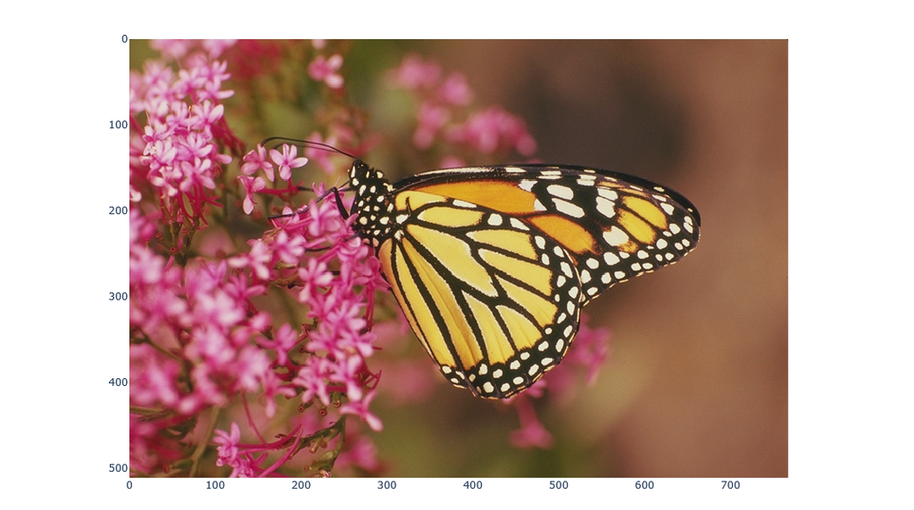

```python
imageButterfly = cv2.imread(r'images/monarch.bmp', cv2.IMREAD_COLOR_RGB)

####
## ENTER CODE HERE
## Geben Si3 die Bildgröße und den Datentyp bitte an
####

#Datentyp:
imageDataType = imageButterfly.dtype
#Bildgröße
imageShape = imageButterfly.shape

# Ausgabe der Daten
print(f'Datentyp des Bildes: {imageDataType}')
print(f'Größe des Bildes: {imageShape}')


# Anzeige des Bildes
fig = px.imshow(imageButterfly)
fig.update_layout(
    margin=dict(l=0, r=0, t=0, b=0),
    width=800,
    height=600
)
fig.show()
```

Sieht Ihr angezeigtes Bild so aus:

[figure not shown]

### Bildausschnitt Wählen / Freistellen

#### Aufgabe

Legen Sie den Bildausschnitt so fest, dass nur der Kopf des Schmetterlings zu sehen ist. Der Bildausschnitt bei Farbbildern kann analog zum Bildausschnitt bei Graustufenbildern. Die Pixelbereiche können über die Doppelpunkt Synthax ausgewählt werden. In der dritten Dimension sind alle Farbkanäle zu wählen `image[startY : endY, startX : endX, 0:3]` bzw. durch den äquivalenten Befehl `image[startY : endY, startX : endX, :]`. Der freistehende Doppelpunkt `:` bedeutet, dass alle Farbkanäle in dieser Dimension gewählt werden.

```python
# Anzeige der Bilder
imageButterfly_ROI = imageButterfly[118:240, 223:300, :]

# Anzeige des Bildes
fig = px.imshow(imageButterfly_ROI)
fig.update_layout(
    margin=dict(l=0, r=0, t=0, b=0),
    width=800,
    height=600
)
fig.show()
```

[output not shown]

### Farbkanäle darstellen

#### Aufgabe

Die Farbkanäle werden in der dritten Dimension des Bildes kodiert. Extrahieren Sie jeweils die Farbkanäle Rot, Grün und Blau und stellen Sie die dazugehörigen Bilder als Graustufenbild dar.

```python
imageButterfly_Red = imageButterfly[:,:,0]
imageButterfly_Green = imageButterfly[:,:,1]
imageButterfly_Blue = imageButterfly[:,:,2]


# Anzeige des Bildes
fig = px.imshow(imageButterfly_Red, color_continuous_scale='gray', title='Roter Farbkanal')
fig.update_layout(
    margin=dict(l=0, r=0, t=50, b=0),
    width=500,
    height=500
)
fig.show()

## Gruenes Bild
fig = px.imshow(imageButterfly_Green, color_continuous_scale='gray', title='Gruener Farbkanal')
fig.update_layout(
    margin=dict(l=0, r=0, t=50, b=0),
    width=500,
    height=500
)
fig.show()

# Blaues BILD
fig = px.imshow(imageButterfly_Blue, color_continuous_scale='gray', title='Blauer Farbkanal')
fig.update_layout(
    margin=dict(l=0, r=0, t=50, b=0),
    width=500,
    height=500
)
fig.show()
```

[output not shown]